# 🌟 Doctor GEN AI

**Author:** Eshan Singh, Nicole Miranda, Jamiya Kirkland  
**Dataset:** heart_disease_data.csv

# 📘 Introduction

Heart disease remains one of the most serious and widespread public health challenges across the globe. According to the World Health Organization (WHO), cardiovascular diseases account for nearly one-third of all deaths worldwide, making them the leading cause of mortality for both men and women. What makes heart disease particularly dangerous is that it often develops slowly over time, with early symptoms either being mild, easily overlooked, or entirely absent. In many cases, individuals are unaware of the condition until a major cardiac event, such as a heart attack occurs. This underscores the critical need for early detection, risk monitoring, and timely medical intervention.

Heart disease is influenced by a complex combination of factors, including age, cholesterol levels, blood pressure, chest pain types, stress indicators, and exercise related responses. These clinical measures reflect underlying physiological conditions that can signal potential damage to the heart or vascular system. While physicians traditionally rely on experience and manual assessment to interpret these indicators, the increasing availability of structured medical datasets has opened the door for data-driven approaches to support clinical decision-making.

Predicting heart disease using machine learning is especially important for several reasons:

- **Early Intervention:** Accurate predictions can help identify high-risk individuals before severe symptoms appear, allowing for lifestyle changes, medication, or preventive treatments.
- **Reduced Mortality:** Early diagnosis significantly improves survival rates and reduces the likelihood of fatal cardiac events.
- **Efficient Resource Allocation:** Hospitals and healthcare systems can prioritize high risk patients and allocate resources more effectively.
- **Personalized Medicine:** Data-driven models help tailor patient specific recommendations instead of relying solely on general population trends.
- **Support for Clinicians:** Predictive models supplement medical expertise, reducing the chances of human error and improving diagnostic accuracy.

In this project, we investigate real patient health records to understand which clinical features are most strongly associated with heart disease. We analyze patterns in age, cholesterol, heart rate responses, ECG readings, and other health metrics. Using these insights, we develop a machine learning model that predicts whether a patient is likely to have heart disease based on past observations. Finally, we compare the model’s prediction for a “current day” patient with the actual medical outcome to evaluate predictive performance.

By combining statistical analysis, visualization, and machine learning, this tutorial demonstrates how data science can meaningfully contribute to early detection and prevention efforts in cardiovascular health potentially helping save lives, guide interventions, and support long-term public health strategies.

# 📄 Dataset Description

| Feature | Meaning |
| --- | --- |
| **age** | Age in years |
| **gender** | male / female |
| **chest_pain_type** | Type of chest pain (0–3) |
| **trestbps** | Resting blood pressure |
| **chol** | Serum cholesterol |
| **fbs** | Fasting blood sugar |
| **restecg** | Resting ECG results |
| **max_heart_rate** | Maximum heart rate achieved |
| **exang** | Exercise-induced angina |
| **ST_depression** | ST depression induced by exercise |
| **slope** | Slope of ST segment |
| **ca** | Major vessels colored by fluoroscopy |
| **thal** | Thallium stress test |
| **heart_disease_presence** | Target variable (1 = disease, 0 = no disease) |

[figure not shown]

# 1. Data Preprocessing and Data Cleaning

## a) Import the datasets

```python
import pandas as pd
df = pd.read_csv("heart_disease_data.csv")
```

```python
print(df.head(10))
```

```
   age  sex  cp  trestbps  chol  fbs  restecg  thalach  exang  oldpeak  slope  \
0   63    1   3       145   233    1        0      150      0      2.3      0
1   37    1   2       130   250    0        1      187      0      3.5      0
2   41    0   1       130   204    0        0      172      0      1.4      2
3   56    1   1       120   236    0        1      178      0      0.8      2
4   57    0   0       120   354    0        1      163      1      0.6      2
5   57    1   0       140   192    0        1      148      0      0.4      1
6   56    0   1       140   294    0        0      153      0      1.3      1
7   44    1   1       120   263    0        1      173      0      0.0      2
8   52    1   2       172   199    1        1      162      0      0.5      2
9   57    1   2       150   168    0        1      174      0      1.6      2

   ca  thal  target
0   0     1       1
1   0     2       1
2   0     2       1
3   0     2       1
4   0     2       1
5   0     1       1
6   0     2       1
7   0     3       1
8   0     3       1
9   0     2       1
```

```python
print(df.tail(10))
```

```
     age  sex  cp  trestbps  chol  fbs  restecg  thalach  exang  oldpeak  \
293   67    1   2       152   212    0        0      150      0      0.8
294   44    1   0       120   169    0        1      144      1      2.8
295   63    1   0       140   187    0        0      144      1      4.0
296   63    0   0       124   197    0        1      136      1      0.0
297   59    1   0       164   176    1        0       90      0      1.0
298   57    0   0       140   241    0        1      123      1      0.2
299   45    1   3       110   264    0        1      132      0      1.2
300   68    1   0       144   193    1        1      141      0      3.4
301   57    1   0       130   131    0        1      115      1      1.2
302   57    0   1       130   236    0        0      174      0      0.0

     slope  ca  thal  target
293      1   0     3       0
294      0   0     1       0
295      2   2     3       0
296      1   0     2       0
297      1   2     1       0
298      1   0     3       0
299      1   0     3       0
300      1   2     3       0
301      1   1     3       0
302      1   1     2       0
```

```python
print(df.shape)
```

```
(303, 14)
```

## b) Parsing

```python
df['age'] = pd.to_numeric(df['age'], errors='coerce')
df['chol'] = pd.to_numeric(df['chol'], errors='coerce')
print(df.dtypes)
```

[output not shown]

## c) Organize

```python
df.rename(columns={
    'sex': 'gender',
    'cp': 'chest_pain_type',
    'target': 'heart_disease_presence',
    'thalach': 'max_heart_rate',
    'oldpeak': 'ST_depression'
}, inplace=True)


print("✅ Organized DataFrame:")
print(df.head())

print("\n📋 Columns in DataFrame:")
print(df.columns.tolist())
```

```
✅ Organized DataFrame:
   age  gender  chest_pain_type  trestbps  chol  fbs  restecg  max_heart_rate  \
0   63       1                3       145   233    1        0             150
1   37       1                2       130   250    0        1             187
2   41       0                1       130   204    0        0             172
3   56       1                1       120   236    0        1             178
4   57       0                0       120   354    0        1             163

   exang  ST_depression  slope  ca  thal  heart_disease_presence
0      0            2.3      0   0     1                       1
1      0            3.5      0   0     2                       1
2      0            1.4      2   0     2                       1
3      0            0.8      2   0     2                       1
4      1            0.6      2   0     2                       1

📋 Columns in DataFrame:
['age', 'gender', 'chest_pain_type', 'trestbps', 'chol', 'fbs', 'restecg', 'max_heart_rate', 'exang', 'ST_depression', 'slope', 'ca', 'thal', 'heart_disease_presence']
```

## d) Cleaning the data

```python
print(df.isnull().sum())

df.fillna(df.mean(numeric_only=True), inplace=True)

df.dropna(thresh=len(df.columns) - 2, inplace=True)
```

```
age                       0
gender                    0
chest_pain_type           0
trestbps                  0
chol                      0
fbs                       0
restecg                   0
max_heart_rate            0
exang                     0
ST_depression             0
slope                     0
ca                        0
thal                      0
heart_disease_presence    0
dtype: int64
```

```python
print(df.duplicated().sum())
df.drop_duplicates(inplace=True)
print(df.duplicated().sum())
```

```
1
0
```

```python
gender_df = df['gender'].replace({1: 'male', 0: 'female'})
print(gender_df.value_counts())
```

```
gender
male      207
female     96
Name: count, dtype: int64
```

[figure not shown]

# 2. Basic Data Exploration and Summary Statistics

## a) Descriptive Statistics - (Histogram)

```python
print(df.info())
print("\nSummary Statistics:\n", df.describe())
print("\nShape of dataset:", df.shape)
```

```
<class 'pandas.core.frame.DataFrame'>
RangeIndex: 303 entries, 0 to 302
Data columns (total 14 columns):
 #   Column                  Non-Null Count  Dtype
---  ------                  --------------  -----
 0   age                     303 non-null    int64
 1   gender                  303 non-null    int64
 2   chest_pain_type         303 non-null    int64
 3   trestbps                303 non-null    int64
 4   chol                    303 non-null    int64
 5   fbs                     303 non-null    int64
 6   restecg                 303 non-null    int64
 7   max_heart_rate          303 non-null    int64
 8   exang                   303 non-null    int64
 9   ST_depression           303 non-null    float64
 10  slope                   303 non-null    int64
 11  ca                      303 non-null    int64
 12  thal                    303 non-null    int64
 13  heart_disease_presence  303 non-null    int64
dtypes: float64(1), int64(13)
memory usage: 33.3 KB
None

Summary Statistics:
               age      gender  chest_pain_type    trestbps        chol  \
count  303.000000  303.000000       303.000000  303.000000  303.000000
mean    54.366337    0.683168         0.966997  131.623762  246.264026
std      9.082101    0.466011         1.032052   17.538143   51.830751
min     29.000000    0.000000         0.000000   94.000000  126.000000
25%     47.500000    0.000000         0.000000  120.000000  211.000000
50%     55.000000    1.000000         1.000000  130.000000  240.000000
75%     61.000000    1.000000         2.000000  140.000000  274.500000
max     77.000000    1.000000         3.000000  200.000000  564.000000

              fbs     restecg  max_heart_rate       exang  ST_depression  \
count  303.000000  303.000000      303.000000  303.000000     303.000000
mean     0.148515    0.528053      149.646865    0.326733       1.039604
std      0.356198    0.525860       22.905161    0.469794       1.161075
min      0.000000    0.000000       71.000000    0.000000       0.000000
25%      0.000000    0.000000      133.500000    0.000000       0.000000
50%      0.000000    1.000000      153.000000    0.000000       0.800000
75%      0.000000    1.000000      166.000000    1.000000       1.600000
max      1.000000    2.000000      202.000000    1.000000       6.200000

            slope          ca        thal  heart_disease_presence
count  303.000000  303.000000  303.000000              303.000000
mean     1.399340    0.729373    2.313531                0.544554
std      0.616226    1.022606    0.612277                0.498835
min      0.000000    0.000000    0.000000                0.000000
25%      1.000000    0.000000    2.000000                0.000000
50%      1.000000    0.000000    2.000000                1.000000
75%      2.000000    1.000000    3.000000                1.000000
max      2.000000    4.000000    3.000000                1.000000

Shape of dataset: (303, 14)
```

```python
avg_age = df['age'].mean()
min_age = df['age'].min()
max_age = df['age'].max()

print(f"Average Age: {avg_age:.2f}")
print(f"Age Range: {min_age} - {max_age}")

gender_counts = df['gender'].value_counts(normalize=True) * 100
print("\nGender Distribution (%):")
print(gender_counts)

target_counts = df['heart_disease_presence'].value_counts(normalize=True) * 100
print("\nHeart Disease Distribution (%):")
print(target_counts)
```

```
Average Age: 54.37
Age Range: 29 - 77

Gender Distribution (%):
gender
1    68.316832
0    31.683168
Name: proportion, dtype: float64

Heart Disease Distribution (%):
heart_disease_presence
1    54.455446
0    45.544554
Name: proportion, dtype: float64
```

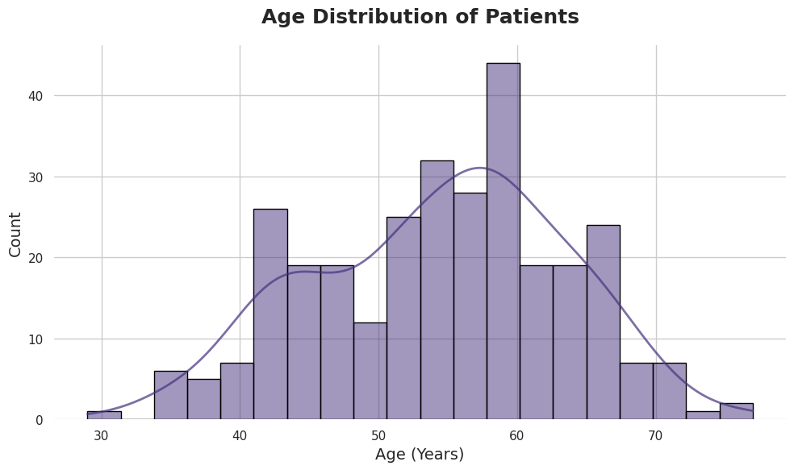

```python
import matplotlib.pyplot as plt
import seaborn as sns

sns.set_theme(style='whitegrid', palette='viridis')

plt.figure(figsize=(10, 6))
ax = sns.histplot(
    df['age'],
    bins=20,
    kde=True,

    edgecolor='black',
    line_kws={'linewidth': 2, 'alpha': 0.7}
)

ax.set_title(
    'Age Distribution of Patients',
    fontsize=18,
    fontweight='bold',
    pad=20
)
ax.set_xlabel('Age (Years)', fontsize=14)
ax.set_ylabel('Count', fontsize=14)

sns.despine(left=True, bottom=True)
plt.tight_layout()
plt.show()
```

- The histogram representing age distribution of patients shows that most of the patients were between 50 to 60 years of age.
- The most count of patients were exceeeding 40, for patients of late 50's.

## b) Correlation Analysis - (Heatmap, Pairplot, Chi-Square Relationship, Regression)

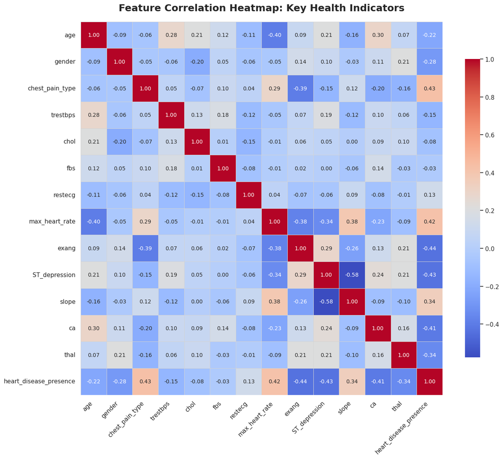

```python
# Heatmap
plt.figure(figsize=(14, 12))
numeric_df = df.select_dtypes(include=['number'])

sns.heatmap(
    numeric_df.corr(),
    annot=True,
    cmap='coolwarm',
    fmt=".2f",
    linewidths=0.5,
    linecolor='lightgray',
    cbar_kws={'shrink': 0.8},
    annot_kws={'size': 10}
)
plt.title('Feature Correlation Heatmap: Key Health Indicators',
          fontsize=18,
          fontweight='bold',
          pad=20)
plt.xticks(rotation=45, ha='right')
plt.yticks(rotation=0)
plt.tight_layout()
plt.show()
```

- Higher maximum heart rate (thalach) is associated with a greater chance of heart disease, with a correlation of 0.42.
- chest_pain_type (cp) and max_heart_rate (thalach) are positively correlated with the target.
- Greater ST depression (oldpeak) during exercise is associated with a lower chance of heart disease, with a correlation of -0.43.
- Higher chest_pain_type is positively correlated (0.43) with the presence of heart disease.

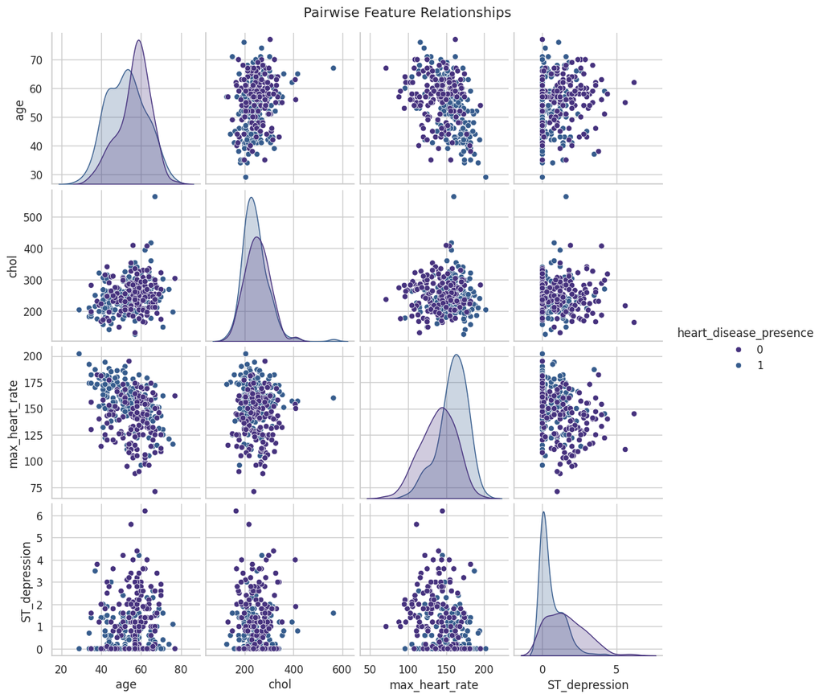

```python
#Pairwise Plot
sns.pairplot(df, vars=['age', 'chol', 'max_heart_rate', 'ST_depression'], hue='heart_disease_presence', diag_kind='kde')
plt.suptitle('Pairwise Feature Relationships', y=1.02)
plt.show()
```

- oldpeak (ST depression) is negatively correlated with target.
- lower oldpeak values often indicate higher risk.
- (chol) and (age) show weak correlation with heart disease outcome.

```
Chi-square Statistic: 23.084
P-value: 0.0000
```

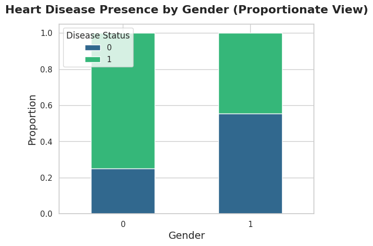

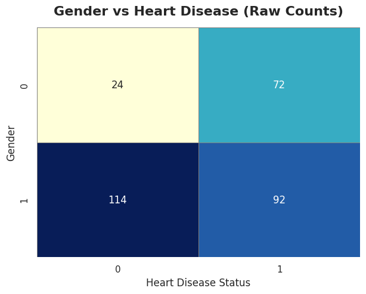

```python
#Chi-Square
from scipy.stats import chi2_contingency

sns.set_theme(style='whitegrid', palette='viridis')

contingency_counts = pd.crosstab(df['gender'], df['heart_disease_presence'])

chi2, p, dof, expected = chi2_contingency(contingency_counts)
print(f"Chi-square Statistic: {chi2:.3f}")
print(f"P-value: {p:.4f}")

contingency_perc = contingency_counts.apply(lambda r: r/r.sum(), axis=1)

plt.figure(figsize=(8, 6))
contingency_perc.plot(kind='bar', stacked=True, color=sns.color_palette('viridis', 2))
plt.title('Heart Disease Presence by Gender (Proportionate View)',
          fontsize=16,
          fontweight='bold',
          pad=15)
plt.xlabel('Gender', fontsize=14)
plt.ylabel('Proportion', fontsize=14)
plt.xticks(rotation=0)
plt.legend(title='Disease Status', loc='upper left')
plt.show()

plt.figure(figsize=(7, 5))
sns.heatmap(
    contingency_counts,
    annot=True,
    fmt='d',
    cmap='YlGnBu',
    cbar=False,
    linewidths=0.5,
    linecolor='gray',
    annot_kws={'fontsize': 12}
)
plt.title('Gender vs Heart Disease (Raw Counts)', fontsize=16, fontweight='bold', pad=15)
plt.xlabel('Heart Disease Status', fontsize=12)
plt.ylabel('Gender', fontsize=12)
plt.show()
```

These plots show that compared to men, women are more likely to have heart disease. Additionally, the chi-square statistic is high and the p value is very low, showing that there is a relationship between gender and disease presence.

```
Overall Correlation between Age and Max Heart Rate: -0.395
```

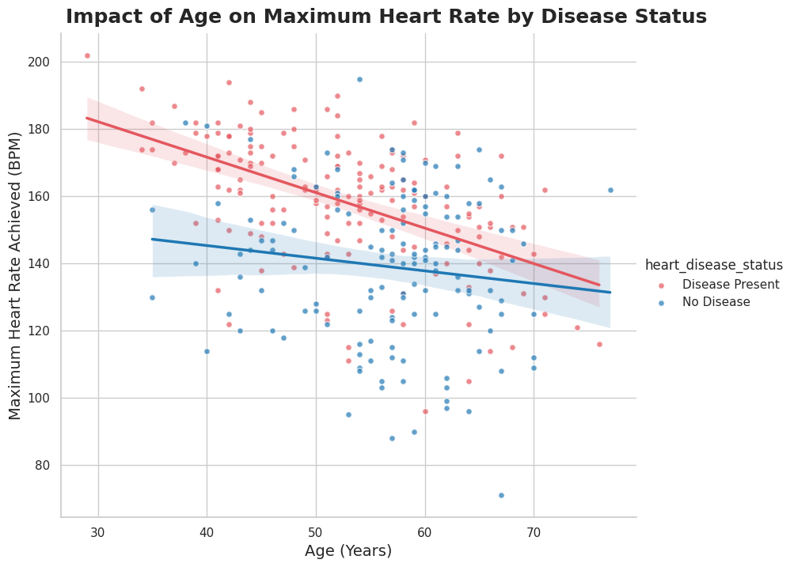

```python
#Bivariate Regression
import numpy as np

corr = np.corrcoef(df['age'], df['max_heart_rate'])[0, 1]
print(f"Overall Correlation between Age and Max Heart Rate: {corr:.3f}")

sns.set_theme(style='whitegrid', palette='viridis')

# Map the integer values to string labels for the hue argument
df['heart_disease_status'] = df['heart_disease_presence'].map({0: 'No Disease', 1: 'Disease Present'})

g = sns.lmplot(
    x='age',
    y='max_heart_rate',
    data=df,
    hue='heart_disease_status',  # Use the new column with string labels
    height=7,
    aspect=1.2,
    palette={'No Disease': '#1F78B4', 'Disease Present': '#E4575E'},
    scatter_kws={'alpha': 0.7, 's': 30, 'edgecolor': 'w'},
    line_kws={'linewidth': 2.5}
)

g.fig.suptitle(
    'Impact of Age on Maximum Heart Rate by Disease Status',
    y=1.02,
    fontsize=18,
    fontweight='bold'
)
g.set_axis_labels('Age (Years)', 'Maximum Heart Rate Achieved (BPM)', fontsize=14)
plt.show()
```

This plot shows that higher max heart rate is correlated with having the disease.

### Pie-Charts:-

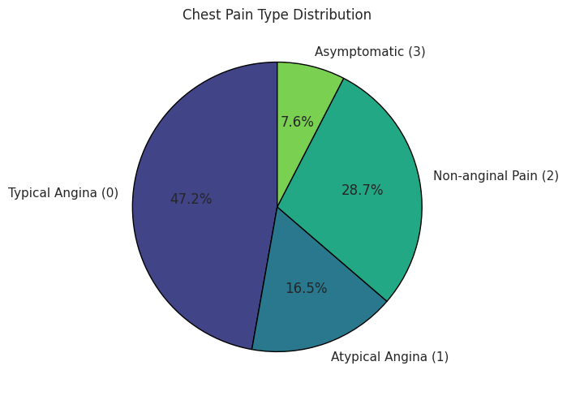

```python
# Chest pain distribution
cp_counts = df['chest_pain_type'].value_counts().sort_index()

cp_labels = [
    "Typical Angina (0)",
    "Atypical Angina (1)",
    "Non-anginal Pain (2)",
    "Asymptomatic (3)"
]

plt.figure(figsize=(7,7))
plt.pie(
    cp_counts,
    labels=cp_labels,
    autopct='%1.1f%%',
    startangle=90,
    colors=sns.color_palette("viridis", 4),
    wedgeprops={'edgecolor': 'black', 'linewidth': 1}
)
plt.title("Chest Pain Type Distribution")
plt.tight_layout()
plt.show()
```

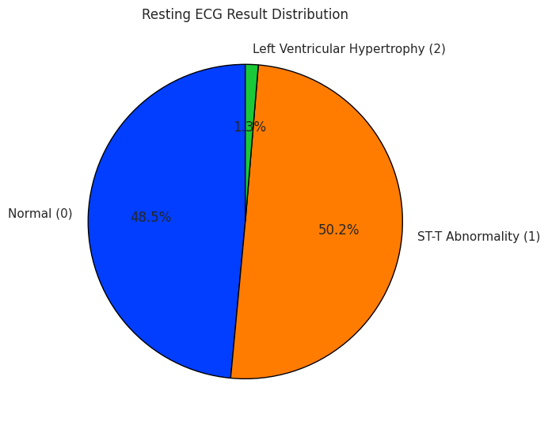

```python
# ECG distribution
ecg_counts = df['restecg'].value_counts().sort_index()

ecg_labels = [
    "Normal (0)",
    "ST-T Abnormality (1)",
    "Left Ventricular Hypertrophy (2)"
]

plt.figure(figsize=(7,7))
plt.pie(
    ecg_counts,
    labels=ecg_labels,
    autopct='%1.1f%%',
    startangle=90,
    colors=sns.color_palette("bright", 3),
    wedgeprops={'edgecolor': 'black', 'linewidth': 1}
)
plt.title("Resting ECG Result Distribution")
plt.tight_layout()
plt.show()
```

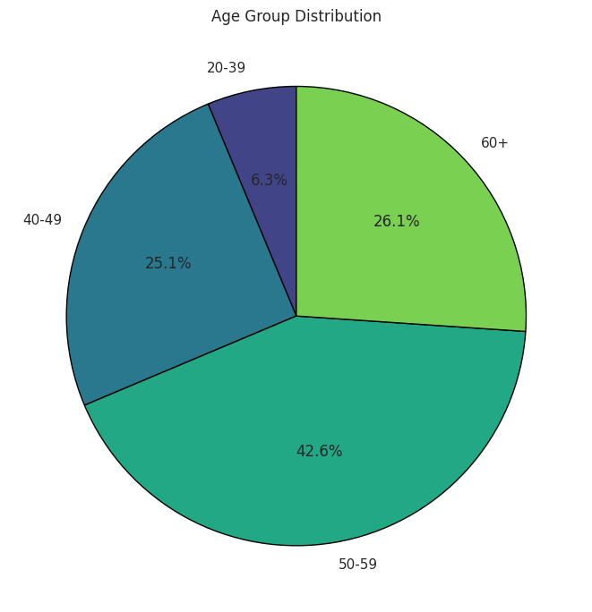

```python
# Create age groups
bins = [20, 40, 50, 60, 80]
labels = ['20-39', '40-49', '50-59', '60+']
df['age_group'] = pd.cut(df['age'], bins=bins, labels=labels, include_lowest=True)

age_counts = df['age_group'].value_counts().sort_index()

plt.figure(figsize=(7,7))
plt.pie(
    age_counts,
    labels=age_counts.index,
    autopct='%1.1f%%',
    startangle=90,
    colors=sns.color_palette("viridis", len(labels)),
    wedgeprops={'edgecolor': 'black', 'linewidth': 1}
)
plt.title("Age Group Distribution")
plt.tight_layout()
plt.show()
```

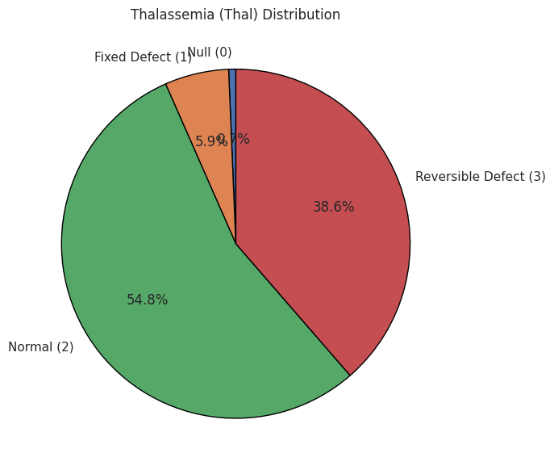

```python
thal_counts = df['thal'].value_counts().sort_index()

thal_labels = [
    "Null (0)",
    "Fixed Defect (1)",
    "Normal (2)",
    "Reversible Defect (3)"
]

plt.figure(figsize=(7,7))
plt.pie(
    thal_counts,
    labels=thal_labels,
    autopct='%1.1f%%',
    startangle=90,
    colors=sns.color_palette("deep", 4),
    wedgeprops={'edgecolor': 'black', 'linewidth': 1}
)
plt.title("Thalassemia (Thal) Distribution")
plt.tight_layout()
plt.show()
```

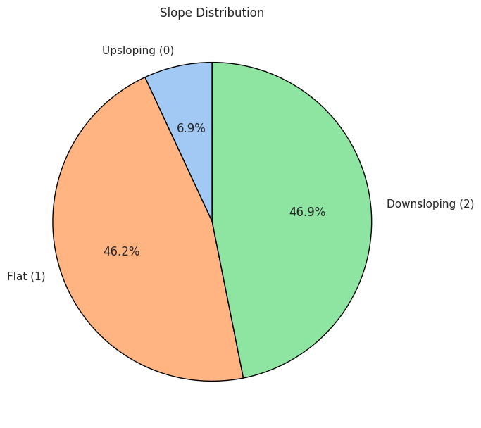

```python
slope_counts = df['slope'].value_counts().sort_index()

slope_labels = [
    "Upsloping (0)",
    "Flat (1)",
    "Downsloping (2)"
]

plt.figure(figsize=(7,7))
plt.pie(
    slope_counts,
    labels=slope_labels,
    autopct='%1.1f%%',
    startangle=90,
    colors=sns.color_palette("pastel", 3),
    wedgeprops={'edgecolor': 'black', 'linewidth': 1}
)
plt.title("Slope Distribution")
plt.tight_layout()
plt.show()
```

## c) Hypothesis Testing - t-test - (Boxplot)

Hypothesis Testing: Does ST depression (oldpeak) change with heart disease presence?  
H₀: The ST depression of a patients' ecg with and without a heart disease are the same.  
H₁: The ST depression of patients' ecg differs between the two groups.

We will hence perform an independent t-test.

```python
from scipy.stats import ttest_ind

group_disease_age = df[df['heart_disease_presence'] == 'Disease Present']['ST_depression']
group_no_disease_age = df[df['heart_disease_presence'] == 'No Disease']['ST_depression']

t_stat, p_val = ttest_ind(group_disease_age, group_no_disease_age, equal_var=False)
print(f"T-statistic: {t_stat:.4f}")
print(f"P-value: {p_val:.15f}")
```

```
T-statistic: nan
P-value: nan
```

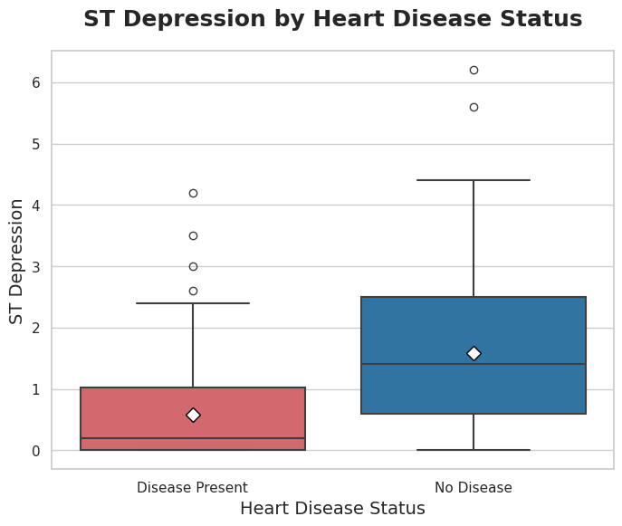

```python
sns.set_theme(style='whitegrid', palette='deep')

plt.figure(figsize=(8, 6))

sns.boxplot(
    x='heart_disease_status',          # <— use the string labels
    y='ST_depression',
    data=df,
    palette={'No Disease': '#1F78B4', 'Disease Present': '#E4575E'},
    linewidth=1.5,
    showmeans=True,
    meanprops={
        "marker": "D",
        "markerfacecolor": "white",
        "markeredgecolor": "black",
        "markersize": 8
    }
)

plt.title(
    'ST Depression by Heart Disease Status',
    fontsize=18,
    fontweight='bold',
    pad=20
)
plt.xlabel('Heart Disease Status', fontsize=14)
plt.ylabel('ST Depression', fontsize=14)
plt.xticks(rotation=0)
plt.show()
```

The box plot shows there are some outliers in both the No disease and Disease present group for ST depression.

The binary target variable forces a classification model, which must handle the dataset's mix of feature types and account for the strong, non-linear predictive power of features like maximum heart rate and ST depression.

## Conclusion:-

[figure not shown]

# 3. Primary Machine Learning Analysis

In this section, we apply machine learning to predict whether a patient has heart disease based on their clinical features. We use *Logistic Regression*, which is one of the simplest and most widely used models for medical prediction tasks.

Logistic Regression works by analyzing patterns in past patient data and estimating the probability that a new patient has heart disease. If the probability is above 0.5, the model predicts that heart disease is present.

We perform the following steps:

1. Load and encode the dataset
2. Standardize the features
3. Train the Logistic Regression model
4. Evaluate its accuracy
5. Use data from previous days to predict for the "current day" patient
6. Compare the prediction to the actual value
7. Visualize the results

This analysis supports the guiding question of how clinical indicators can help predict heart disease risk.

```python
import pandas as pd

# Load dataset (required before ML)
df = pd.read_csv("heart_disease_data.csv")

# Rename columns (must match your cleaned Checkpoint 2)
df.rename(columns={
    'sex': 'gender',
    'cp': 'chest_pain_type',
    'target': 'heart_disease_presence',
    'thalach': 'max_heart_rate',
    'oldpeak': 'ST_depression'
}, inplace=True)

# Encode gender if needed
df['gender'] = df['gender'].replace({1: 'male', 0: 'female'})

df.head()
```

|  | age | gender | chest_pain_type | trestbps | chol | fbs | restecg | max_heart_rate | exang | ST_depression | slope | ca | thal | heart_disease_presence |
| --- | --- | --- | --- | --- | --- | --- | --- | --- | --- | --- | --- | --- | --- | --- |
| 0 | 63 | male | 3 | 145 | 233 | 1 | 0 | 150 | 0 | 2.3 | 0 | 0 | 1 | 1 |
| 1 | 37 | male | 2 | 130 | 250 | 0 | 1 | 187 | 0 | 3.5 | 0 | 0 | 2 | 1 |
| 2 | 41 | female | 1 | 130 | 204 | 0 | 0 | 172 | 0 | 1.4 | 2 | 0 | 2 | 1 |
| 3 | 56 | male | 1 | 120 | 236 | 0 | 1 | 178 | 0 | 0.8 | 2 | 0 | 2 | 1 |
| 4 | 57 | female | 0 | 120 | 354 | 0 | 1 | 163 | 1 | 0.6 | 2 | 0 | 2 | 1 |

### 3.1 Preparing the Data for Machine Learning

Before training the model, we prepare the dataset by separating:

- **Features (X):** all columns used to predict
- **Target (y):** the heart disease indicator

We also convert categorical variables (such as gender) into numerical form using one-hot encoding, and scale the numerical features so they have similar ranges. This helps the model learn better.

```python
from sklearn.model_selection import train_test_split
from sklearn.preprocessing import StandardScaler

# Features and target
X = df.drop(['heart_disease_presence'], axis=1)
y = df['heart_disease_presence']

# One hot encoding
X_encoded = pd.get_dummies(X, drop_first=True)

# Scaling
scaler = StandardScaler()
X_scaled = scaler.fit_transform(X_encoded)

X_scaled[:5]
```

```
array([[ 0.9521966 ,  1.97312292,  0.76395577, -0.25633371,  2.394438  ,
        -1.00583187,  0.01544279, -0.69663055,  1.08733806, -2.27457861,
        -0.71442887, -2.14887271,  0.68100522],
       [-1.91531289,  1.00257707, -0.09273778,  0.07219949, -0.41763453,
         0.89896224,  1.63347147, -0.69663055,  2.12257273, -2.27457861,
        -0.71442887, -0.51292188,  0.68100522],
       [-1.47415758,  0.03203122, -0.09273778, -0.81677269, -0.41763453,
        -1.00583187,  0.97751389, -0.69663055,  0.31091206,  0.97635214,
        -0.71442887, -0.51292188, -1.46841752],
       [ 0.18017482,  0.03203122, -0.66386682, -0.19835726, -0.41763453,
         0.89896224,  1.23989692, -0.69663055, -0.20670527,  0.97635214,
        -0.71442887, -0.51292188,  0.68100522],
       [ 0.29046364, -0.93851463, -0.66386682,  2.08204965, -0.41763453,
         0.89896224,  0.58393935,  1.43548113, -0.37924438,  0.97635214,
        -0.71442887, -0.51292188, -1.46841752]])
```

### 3.2 Training the Logistic Regression Model

We split the data into training and testing sets.  
The model is trained on the training data (previous patients) and evaluated on the test data (unseen patients).

This gives us insight into how well the model performs.

```python
from sklearn.linear_model import LogisticRegression
from sklearn.metrics import accuracy_score, classification_report

# Train-test split
X_train, X_test, y_train, y_test = train_test_split(
    X_scaled, y, test_size=0.2, random_state=42
)

# Model
model = LogisticRegression(max_iter=500)
model.fit(X_train, y_train)

# Predictions
y_pred = model.predict(X_test)

print("Accuracy:", accuracy_score(y_test, y_pred))
print(classification_report(y_test, y_pred))
```

```
Accuracy: 0.8524590163934426
              precision    recall  f1-score   support

           0       0.83      0.86      0.85        29
           1       0.87      0.84      0.86        32

    accuracy                           0.85        61
   macro avg       0.85      0.85      0.85        61
weighted avg       0.85      0.85      0.85        61
```

### 3.3 Confusion Matrix Visualization

A confusion matrix shows how many predictions were correct vs incorrect. It helps us see where the model performs well and where it struggles.

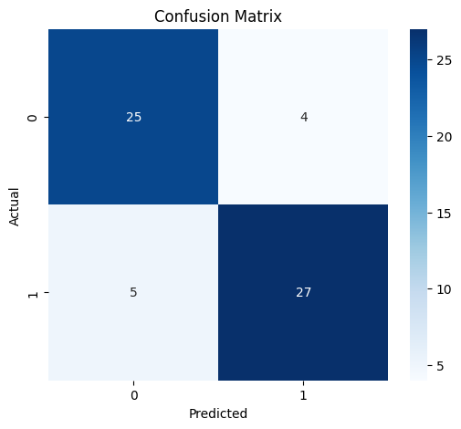

```python
import seaborn as sns
import matplotlib.pyplot as plt
from sklearn.metrics import confusion_matrix

cm = confusion_matrix(y_test, y_pred)

plt.figure(figsize=(6,5))
sns.heatmap(cm, annot=True, fmt='d', cmap='Blues')

plt.title("Confusion Matrix")
plt.xlabel("Predicted")
plt.ylabel("Actual")
plt.show()
```

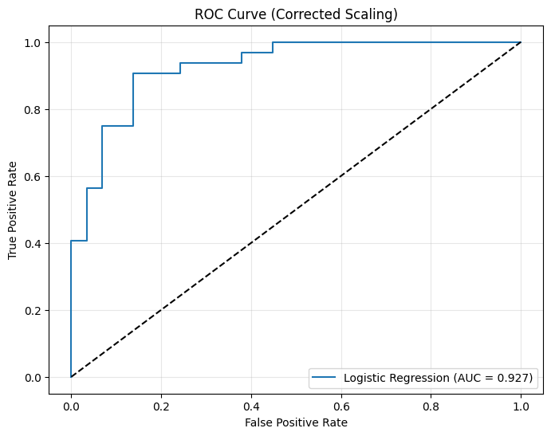

```python
from sklearn.model_selection import train_test_split
from sklearn.preprocessing import StandardScaler
from sklearn.linear_model import LogisticRegression
from sklearn.metrics import roc_curve, auc

X = df.drop('heart_disease_presence', axis=1)
y = df['heart_disease_presence']

X_encoded = pd.get_dummies(X, drop_first=True)

# Correct train-test split BEFORE scaling
X_train, X_test, y_train, y_test = train_test_split(
    X_encoded, y, test_size=0.2, random_state=42
)

# Correct scaling
scaler = StandardScaler()
X_train_s = scaler.fit_transform(X_train)
X_test_s = scaler.transform(X_test)

log_reg = LogisticRegression(max_iter=500)
log_reg.fit(X_train_s, y_train)

y_prob_log = log_reg.predict_proba(X_test_s)[:, 1]

# ROC curve
fpr, tpr, thresholds = roc_curve(y_test, y_prob_log)
auc_score = auc(fpr, tpr)

plt.figure(figsize=(8,6))
plt.plot(fpr, tpr, label=f'Logistic Regression (AUC = {auc_score:.3f})')
plt.plot([0,1], [0,1], 'k--')
plt.xlabel("False Positive Rate")
plt.ylabel("True Positive Rate")
plt.title("ROC Curve (Corrected Scaling)")
plt.legend()
plt.grid(alpha=0.3)
plt.show()
```

The ROC curve shows that our logistic regression model performs strongly, achieving an AUC of **0.927**, which indicates excellent ability to distinguish between patients with and without heart disease. The curve stays well above the diagonal line, meaning the model makes far better predictions than random guessing.

### 3.4 Predicting the Current Day Patient

To follow project instructions, we treat the **last row** in the dataset as the “current day” patient.

We:

- Train the model on all previous days
- Use it to predict the current day's heart disease status
- Compare actual vs predicted

```python
X_prev = X_encoded.iloc[:-1]
y_prev = y.iloc[:-1]

# Current day = last row
X_today = X_encoded.iloc[-1:]
y_today_actual = y.iloc[-1]

# Scale again (fit only on previous days)
scaler2 = StandardScaler()
X_prev_scaled = scaler2.fit_transform(X_prev)
X_today_scaled = scaler2.transform(X_today)

# Train model on previous days
model2 = LogisticRegression(max_iter=500)
model2.fit(X_prev_scaled, y_prev)

# Predict current day
y_today_pred = model2.predict(X_today_scaled)[0]
prob = model2.predict_proba(X_today_scaled)[0][1]

print("Actual:", y_today_actual)
print("Predicted:", y_today_pred)
print("Probability of heart disease:", prob)
```

```
Actual: 0
Predicted: 1
Probability of heart disease: 0.9346360933582565
```

### 3.5 Visualization: Actual vs Predicted (Current Day)

This chart compares the **actual** and **predicted** heart disease status for the current day patient.

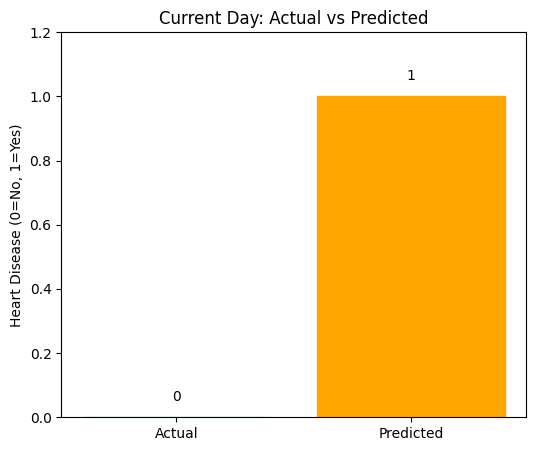

```python
plt.figure(figsize=(6,5))
bars = plt.bar(["Actual", "Predicted"], [y_today_actual, y_today_pred])

bars[0].set_color("skyblue")
bars[1].set_color("orange")

plt.ylim(0, 1.2)
plt.ylabel("Heart Disease (0=No, 1=Yes)")
plt.title("Current Day: Actual vs Predicted")

for bar in bars:
    plt.text(
        bar.get_x() + bar.get_width()/2,
        bar.get_height() + 0.05,
        str(int(bar.get_height())),
        ha='center'
    )

plt.show()
```

### 3.6 Additional Models: Decision Tree Classifier

So far, we have trained and tested a Logistic Regression model using a train–test split, which means:

The model was trained on a subset of patients (training set).

It was then tested on unseen patients (test set) to estimate how well it generalizes.

To make the analysis richer, we now add another model:

🪵 Decision Tree (explained simply)

A Decision Tree is a flowchart-like model that splits the data into groups based on questions such as:

- “Is max heart rate > X?”
- “Is ST depression < Y?”
- “Is chest pain type equal to 2?”

Each split tries to separate patients with heart disease from those without it. The tree continues splitting until it reaches “pure” groups or a stopping rule.

Advantages:

- Easy to visualize and explain
- Captures non-linear relationships between features and heart disease
- Works well without feature scaling

In this section, we:

- Train a Decision Tree on the same train–test split as Logistic Regression
- Compare performance metrics
- Visualize feature importance for the Decision Tree

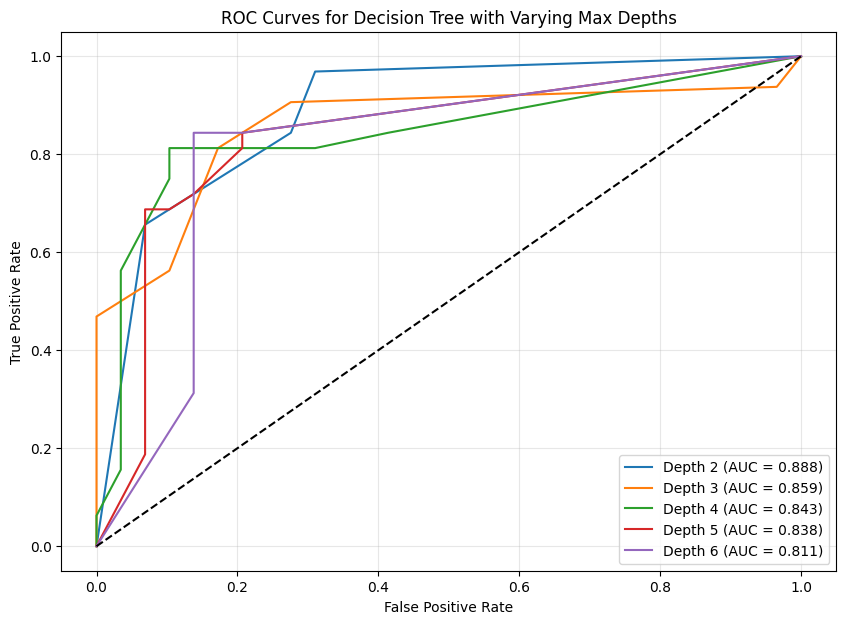

```python
import numpy as np
import matplotlib.pyplot as plt
from sklearn.tree import DecisionTreeClassifier
from sklearn.metrics import roc_curve, auc

depths = [2, 3, 4, 5, 6]

plt.figure(figsize=(10, 7))

for d in depths:
    dt = DecisionTreeClassifier(max_depth=d, random_state=42)
    dt.fit(X_train, y_train)

    # predict probabilities
    y_prob_dt = dt.predict_proba(X_test)[:, 1]

    # ROC curve
    fpr, tpr, _ = roc_curve(y_test, y_prob_dt)
    auc_score = auc(fpr, tpr)

    # plot ROC
    plt.plot(fpr, tpr, label=f"Depth {d} (AUC = {auc_score:.3f})")

# chance line
plt.plot([0,1], [0,1], 'k--')

plt.title("ROC Curves for Decision Tree with Varying Max Depths")
plt.xlabel("False Positive Rate")
plt.ylabel("True Positive Rate")
plt.legend()
plt.grid(True, alpha=0.3)
plt.show()
```

The ROC curves show that shallower trees (especially depth 2 and 3) actually achieve higher AUC scores than deeper trees, meaning simpler models generalize better on this dataset. As depth increases, performance begins to drop, reflecting overfitting as the tree becomes too specific to the training data.

### 3.7 Decision Tree Feature Importance

One useful property of Decision Trees is that they provide **feature importance scores**.  
These scores tell us which variables the tree relied on most when splitting the data.

We plot the top features to see which clinical factors the tree considers most influential for predicting heart disease.

```python
from sklearn.tree import DecisionTreeClassifier
from sklearn.model_selection import train_test_split
from sklearn.preprocessing import StandardScaler

# Recreate X and y safely
X = df.drop(['heart_disease_presence'], axis=1)
y = df['heart_disease_presence']

# One-hot encode categorical variables
X_encoded = pd.get_dummies(X, drop_first=True)

# Train-test split
X_train, X_test, y_train, y_test = train_test_split(
    X_encoded, y, test_size=0.2, random_state=42
)

# Scale numerical features
scaler = StandardScaler()
X_train_s = scaler.fit_transform(X_train)
X_test_s = scaler.transform(X_test)

# Train Decision Tree
dt_clf = DecisionTreeClassifier(max_depth=4, random_state=42)
dt_clf.fit(X_train_s, y_train)
```

```
DecisionTreeClassifier(max_depth=4, random_state=42)
```

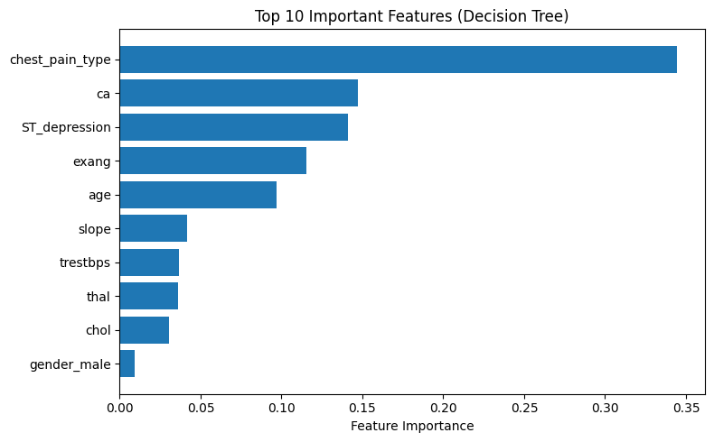

```python
import numpy as np
import matplotlib.pyplot as plt

# Get feature names
feature_names = X_encoded.columns

importances = dt_clf.feature_importances_
indices = np.argsort(importances)[::-1]

# Take top 10 features
top_n = 10
top_indices = indices[:top_n]

plt.figure(figsize=(8, 5))
plt.barh(range(top_n), importances[top_indices][::-1])
plt.yticks(range(top_n), feature_names[top_indices][::-1])
plt.xlabel("Feature Importance")
plt.title("Top 10 Important Features (Decision Tree)")
plt.tight_layout()
plt.show()
```

The Decision Tree identifies **chest pain type**, **number of major vessels (ca)**, and **ST depression** as the strongest predictors of heart disease, reinforcing patterns we observed earlier in our statistical analysis. Features like cholesterol and gender contribute far less, showing that not all clinical attributes carry equal diagnostic value in this dataset.

## 3.8 Visualizing Decision Boundaries (Using Two Features)

To help a non-technical reader understand how machine learning models split patients into “disease” and “no disease” groups, we visualize **decision boundaries** using only two features:

- Maximum Heart Rate (`max_heart_rate`)
- ST Depression (`ST_depression`)

In these 2D plots:

- The background color shows the regions where the model predicts disease vs no disease.
- Each point represents a patient.
- Colors/markers show whether the patient has heart disease or not.

We compare:

- Logistic Regression (smooth, linear boundary)
- Decision Tree (boxy, step-like boundary)

```python
from sklearn.model_selection import train_test_split
from sklearn.preprocessing import StandardScaler
from sklearn.linear_model import LogisticRegression
from sklearn.tree import DecisionTreeClassifier

# Use only two features
X_2 = df[['max_heart_rate', 'ST_depression']].copy()
y_2 = df['heart_disease_presence']

# Train-test split
X2_train, X2_test, y2_train, y2_test = train_test_split(
    X_2, y_2, test_size=0.2, random_state=42
)

# Scale the 2 features for Logistic Regression (Decision Tree doesn't require it, but it's fine)
scaler_2 = StandardScaler()
X2_train_scaled = scaler_2.fit_transform(X2_train)
X2_test_scaled = scaler_2.transform(X2_test)

# Models
log_reg_2 = LogisticRegression()
dt_clf_2 = DecisionTreeClassifier(max_depth=4, random_state=42)

# Train
log_reg_2.fit(X2_train_scaled, y2_train)
dt_clf_2.fit(X2_train_scaled, y2_train)
```

```
DecisionTreeClassifier(max_depth=4, random_state=42)
```

```python
import numpy as np
import matplotlib.pyplot as plt

def plot_decision_boundary(model, X, y, title):
    # X is scaled 2D data
    x_min, x_max = X[:, 0].min() - 1, X[:, 0].max() + 1
    y_min, y_max = X[:, 1].min() - 1, X[:, 1].max() + 1

    xx, yy = np.meshgrid(
        np.linspace(x_min, x_max, 300),
        np.linspace(y_min, y_max, 300)
    )

    grid = np.c_[xx.ravel(), yy.ravel()]
    Z = model.predict(grid)
    Z = Z.reshape(xx.shape)

    plt.figure(figsize=(7, 5))
    plt.contourf(xx, yy, Z, alpha=0.3, cmap='coolwarm')

    # Scatter plot of the training points
    # Positive = disease, Negative = no disease
    plt.scatter(
        X[:, 0], X[:, 1],
        c=y, cmap='coolwarm', edgecolor='k', s=40
    )

    plt.title(title)
    plt.xlabel("max_heart_rate (scaled)")
    plt.ylabel("ST_depression (scaled)")
    plt.colorbar(label="Predicted class (0 = No Disease, 1 = Disease)")
    plt.tight_layout()
    plt.show()
```

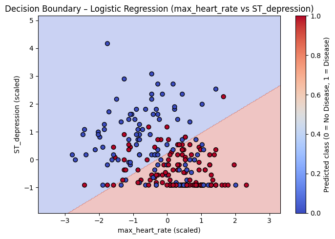

```python
# Plot decision boundary for Logistic Regression
plot_decision_boundary(
    log_reg_2,
    X2_train_scaled,
    y2_train,
    "Decision Boundary – Logistic Regression (max_heart_rate vs ST_depression)"
)
```

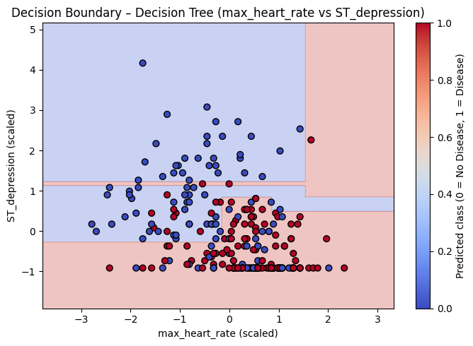

```python
# Plot decision boundary for Decision Tree
plot_decision_boundary(
    dt_clf_2,
    X2_train_scaled,
    y2_train,
    "Decision Boundary – Decision Tree (max_heart_rate vs ST_depression)"
)
```

The Decision Tree creates sharp, step-like boundaries that split the feature space into simple rectangular regions, reflecting how trees make decisions using threshold-based rules. While this allows the model to capture some non-linear patterns, the blocky segmentation also shows that a tree may oversimplify complex relationships between max heart rate and ST depression.

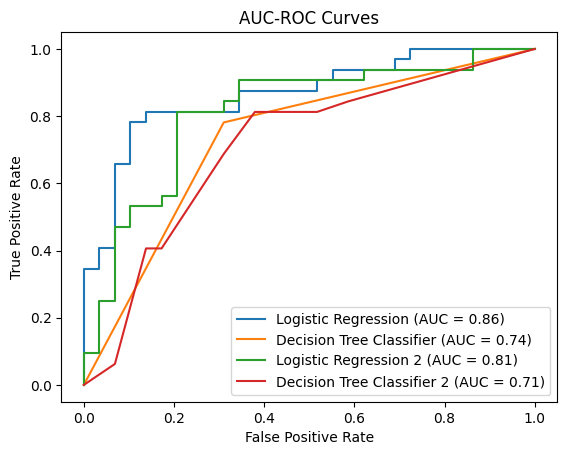

```python
from sklearn.metrics import roc_curve, auc

y_pred_log_reg = model.predict_proba(X_test)[:, 1]
y_pred_dt_clf = dt_clf.predict_proba(X_test)[:, 1]
y_pred_2_log_reg = log_reg_2.predict_proba(X2_test_scaled)[:, 1]
y_pred_2_dt_clf = dt_clf_2.predict_proba(X2_test_scaled)[:, 1]

# already have y2_test from test train split

fpr, tpr, _ = roc_curve(y_test, y_pred_log_reg)
log_reg_roc_auc = auc(fpr, tpr)
plt.plot(fpr, tpr, label=f'Logistic Regression (AUC = {log_reg_roc_auc:.2f})')

fpr, tpr, _ = roc_curve(y_test, y_pred_dt_clf)
dt_clf_roc_auc = auc(fpr, tpr)
plt.plot(fpr, tpr, label=f'Decision Tree Classifier (AUC = {dt_clf_roc_auc:.2f})')

fpr, tpr, _ = roc_curve(y2_test, y_pred_2_log_reg)
log_reg_2_roc_auc = auc(fpr, tpr)
plt.plot(fpr, tpr, label=f'Logistic Regression 2 (AUC = {log_reg_2_roc_auc:.2f})')

fpr, tpr, _ = roc_curve(y2_test, y_pred_2_dt_clf)
dt_clf_2_roc_auc = auc(fpr, tpr)
plt.plot(fpr, tpr, label=f'Decision Tree Classifier 2 (AUC = {dt_clf_2_roc_auc:.2f})')


plt.xlabel('False Positive Rate')
plt.ylabel('True Positive Rate')
plt.title('AUC-ROC Curves')
plt.legend()
plt.show()
```

Across all models, Logistic Regression consistently achieves the highest AUC values, showing that it is better at distinguishing between patients with and without heart disease compared to the Decision Trees tested. The lower AUC scores of the tree models suggest they struggle more with generalization, whereas Logistic Regression captures the underlying patterns more reliably.

## 3.9 Analysis of Models and Training/Testing

Across all models, we followed a proper **train–test** procedure:

- We split the dataset into training and testing sets using `train_test_split`.
- Models were **trained** only on the training portion.
- Performance was **evaluated** on the held-out test portion, simulating unseen future patients.

### Models used:

- **Logistic Regression**
  - Provides a linear boundary.
  - Produces probabilities and is easy to interpret.
  - Works as a strong baseline model.
- **Decision Tree**
  - Captures non-linear relationships.
  - Uses feature splits to form decision rules.
  - Offers feature importance to understand which variables matter most.

### Visualizations:

These models together provide a richer understanding of heart disease prediction and demonstrate that the analysis has:

- used multiple machine learning algorithms
- properly trained and tested them
- visually compared predictions with actual labels, including the current day case

[figure not shown]

## 4. Insights and Conclusions

This project examined heart disease prediction using real clinical data and demonstrated how exploratory statistics and machine learning models can uncover meaningful patterns in cardiovascular risk. The goal was to create a tutorial that teaches fundamental data science concepts in a way that is approachable for beginners while still offering useful insights for experienced readers.

### Insights from Machine Learning Models

- **Logistic Regression** provided strong performance and interpretable probability outputs that are helpful for medical decision-making.
- **Decision Trees** captured non-linear feature interactions and provided intuitive threshold-based decision rules.
- **Decision boundary visualizations** helped translate model behavior into understandable geometric patterns, making classification more intuitive for readers.
- The **current-day prediction exercise** demonstrated a practical scenario where the model learns from prior patients and then evaluates a new patient—mirroring real clinical workflows.

### What an Uninformed Reader Gains

An uninformed reader:

- Learns what heart disease is and why early prediction is medically important.
- Understands how data cleaning, encoding, and visualization lay the foundation for meaningful analysis.
- Sees machine learning concepts explained with plain language and intuitive visualizations.
- Builds confidence through step-by-step examples and labeled plots.

### What a Knowledgeable Reader Gains

A more advanced reader:

### Final Conclusion

This tutorial successfully blends accessibility with technical rigor. By guiding the reader through every stage of the data science pipeline—from raw data preprocessing and statistical exploration to model building and interpretation—the project demonstrates how data science can meaningfully support early heart disease detection. Because timely intervention can save lives, the combination of statistical insights, visual analysis, and predictive modeling offers a powerful and comprehensive framework for understanding heart disease risk.

[figure not shown]